[figure not shown]

# Project: Investigate a Dataset - [TMDB]

- Introduction
- Data Wrangling
- Exploratory Data Analysis
- Conclusions

## Introduction

### Dataset Description

> This data set contains information about 10,000 movies collected from The Movie Database (TMDb), including user ratings and revenue. The dataset file `'tmdb-movies.csv'` can be downloaded [here](https://www.google.com/url?q=https://d17h27t6h515a5.cloudfront.net/topher/2017/October/59dd1c4c_tmdb-movies/tmdb-movies.csv&sa=D&source=editors&ust=1642714551547410&usg=AOvVaw0ORMav7cVpajE2y4ZwV34K).  
> Certain columns, like `‘cast’` and `‘genres’`, contain multiple values separated by pipe `(|)` characters.  
> There are some odd characters in the `‘cast’` column. Don’t worry about cleaning them. You can leave them as is.  
> The final two columns ending with `“_adj”` show the budget and revenue of the associated movie in terms of 2010 dollars, accounting for inflation over time.

### Question(s) for Analysis

> 1. How many movies were released in each genre?
> 2. Which genres are most popular from year to year?
> 3. Which genre(s) is/are all the time popular?
> 4. Which movie title was repeated the most, and which release was the most popular?
> 5. What kinds of properties are associated with movies that have high revenues?

```python
# import statments for all packages used in analysis
import datetime

import numpy as np
import pandas as pd

import matplotlib.pyplot as plt
%matplotlib inline

import wordcloud
import seaborn as sns

# Check pandas version to use dataframe.explode() function. Should be 0.25.0 or higher
pd.__version__
```

```
'1.3.5'
```

## Data Wrangling

> In this section, I will load in the data, check for cleanliness, and then trim and clean my dataset for analysis.

### Assessing

> I will start by loading my data and print out few lines. Perform operations to inspect data types and look for instances of missing or possibly errant data.

```python
# load the dataset from source file
df = pd.read_csv('tmdb-movies.csv', sep=(','))
```

```python
# print few top lines
df.head(3)
```

|  | id | imdb_id | popularity | budget | revenue | original_title | cast | homepage | director | tagline | ... | overview | runtime | genres | production_companies | release_date | vote_count | vote_average | release_year | budget_adj | revenue_adj |
| --- | --- | --- | --- | --- | --- | --- | --- | --- | --- | --- | --- | --- | --- | --- | --- | --- | --- | --- | --- | --- | --- |
| 0 | 135397 | tt0369610 | 32.985763 | 150000000 | 1513528810 | Jurassic World | Chris Pratt\|Bryce Dallas Howard\|Irrfan Khan\|Vi... | http://www.jurassicworld.com/ | Colin Trevorrow | The park is open. | ... | Twenty-two years after the events of Jurassic ... | 124 | Action\|Adventure\|Science Fiction\|Thriller | Universal Studios\|Amblin Entertainment\|Legenda... | 6/9/15 | 5562 | 6.5 | 2015 | 1.379999e+08 | 1.392446e+09 |
| 1 | 76341 | tt1392190 | 28.419936 | 150000000 | 378436354 | Mad Max: Fury Road | Tom Hardy\|Charlize Theron\|Hugh Keays-Byrne\|Nic... | http://www.madmaxmovie.com/ | George Miller | What a Lovely Day. | ... | An apocalyptic story set in the furthest reach... | 120 | Action\|Adventure\|Science Fiction\|Thriller | Village Roadshow Pictures\|Kennedy Miller Produ... | 5/13/15 | 6185 | 7.1 | 2015 | 1.379999e+08 | 3.481613e+08 |
| 2 | 262500 | tt2908446 | 13.112507 | 110000000 | 295238201 | Insurgent | Shailene Woodley\|Theo James\|Kate Winslet\|Ansel... | http://www.thedivergentseries.movie/#insurgent | Robert Schwentke | One Choice Can Destroy You | ... | Beatrice Prior must confront her inner demons ... | 119 | Adventure\|Science Fiction\|Thriller | Summit Entertainment\|Mandeville Films\|Red Wago... | 3/18/15 | 2480 | 6.3 | 2015 | 1.012000e+08 | 2.716190e+08 |

3 rows × 21 columns

```python
# print few bottom lines
df.tail()
```

|  | id | imdb_id | popularity | budget | revenue | original_title | cast | homepage | director | tagline | ... | overview | runtime | genres | production_companies | release_date | vote_count | vote_average | release_year | budget_adj | revenue_adj |
| --- | --- | --- | --- | --- | --- | --- | --- | --- | --- | --- | --- | --- | --- | --- | --- | --- | --- | --- | --- | --- | --- |
| 10861 | 21 | tt0060371 | 0.080598 | 0 | 0 | The Endless Summer | Michael Hynson\|Robert August\|Lord 'Tally Ho' B... | NaN | Bruce Brown | NaN | ... | The Endless Summer, by Bruce Brown, is one of ... | 95 | Documentary | Bruce Brown Films | 6/15/66 | 11 | 7.4 | 1966 | 0.000000 | 0.0 |
| 10862 | 20379 | tt0060472 | 0.065543 | 0 | 0 | Grand Prix | James Garner\|Eva Marie Saint\|Yves Montand\|Tosh... | NaN | John Frankenheimer | Cinerama sweeps YOU into a drama of speed and ... | ... | Grand Prix driver Pete Aron is fired by his te... | 176 | Action\|Adventure\|Drama | Cherokee Productions\|Joel Productions\|Douglas ... | 12/21/66 | 20 | 5.7 | 1966 | 0.000000 | 0.0 |
| 10863 | 39768 | tt0060161 | 0.065141 | 0 | 0 | Beregis Avtomobilya | Innokentiy Smoktunovskiy\|Oleg Efremov\|Georgi Z... | NaN | Eldar Ryazanov | NaN | ... | An insurance agent who moonlights as a carthie... | 94 | Mystery\|Comedy | Mosfilm | 1/1/66 | 11 | 6.5 | 1966 | 0.000000 | 0.0 |
| 10864 | 21449 | tt0061177 | 0.064317 | 0 | 0 | What's Up, Tiger Lily? | Tatsuya Mihashi\|Akiko Wakabayashi\|Mie Hama\|Joh... | NaN | Woody Allen | WOODY ALLEN STRIKES BACK! | ... | In comic Woody Allen's film debut, he took the... | 80 | Action\|Comedy | Benedict Pictures Corp. | 11/2/66 | 22 | 5.4 | 1966 | 0.000000 | 0.0 |
| 10865 | 22293 | tt0060666 | 0.035919 | 19000 | 0 | Manos: The Hands of Fate | Harold P. Warren\|Tom Neyman\|John Reynolds\|Dian... | NaN | Harold P. Warren | It's Shocking! It's Beyond Your Imagination! | ... | A family gets lost on the road and stumbles up... | 74 | Horror | Norm-Iris | 11/15/66 | 15 | 1.5 | 1966 | 127642.279154 | 0.0 |

5 rows × 21 columns

```python
# see how many rows and columns
df.shape
```

```
(10866, 21)
```

```python
# inspect data information (column names, non-null count, data types)
df.info()
```

```
<class 'pandas.core.frame.DataFrame'>
RangeIndex: 10866 entries, 0 to 10865
Data columns (total 21 columns):
 #   Column                Non-Null Count  Dtype
---  ------                --------------  -----
 0   id                    10866 non-null  int64
 1   imdb_id               10856 non-null  object
 2   popularity            10866 non-null  float64
 3   budget                10866 non-null  int64
 4   revenue               10866 non-null  int64
 5   original_title        10866 non-null  object
 6   cast                  10790 non-null  object
 7   homepage              2936 non-null   object
 8   director              10822 non-null  object
 9   tagline               8042 non-null   object
 10  keywords              9373 non-null   object
 11  overview              10862 non-null  object
 12  runtime               10866 non-null  int64
 13  genres                10843 non-null  object
 14  production_companies  9836 non-null   object
 15  release_date          10866 non-null  object
 16  vote_count            10866 non-null  int64
 17  vote_average          10866 non-null  float64
 18  release_year          10866 non-null  int64
 19  budget_adj            10866 non-null  float64
 20  revenue_adj           10866 non-null  float64
dtypes: float64(4), int64(6), object(11)
memory usage: 1.7+ MB
```

*All data types are okay except for `'release_date'`.*

```python
# look for missing data
df.isnull().sum()
```

```
id                         0
imdb_id                   10
popularity                 0
budget                     0
revenue                    0
original_title             0
cast                      76
homepage                7930
director                  44
tagline                 2824
keywords                1493
overview                   4
runtime                    0
genres                    23
production_companies    1030
release_date               0
vote_count                 0
vote_average               0
release_year               0
budget_adj                 0
revenue_adj                0
dtype: int64
```

```python
# look for duplicated data
df.duplicated().sum()
```

```
1
```

```python
# descriptive statistics summary
df.describe()
```

|  | id | popularity | budget | revenue | runtime | vote_count | vote_average | release_year | budget_adj | revenue_adj |
| --- | --- | --- | --- | --- | --- | --- | --- | --- | --- | --- |
| count | 10866.000000 | 10866.000000 | 1.086600e+04 | 1.086600e+04 | 10866.000000 | 10866.000000 | 10866.000000 | 10866.000000 | 1.086600e+04 | 1.086600e+04 |
| mean | 66064.177434 | 0.646441 | 1.462570e+07 | 3.982332e+07 | 102.070863 | 217.389748 | 5.974922 | 2001.322658 | 1.755104e+07 | 5.136436e+07 |
| std | 92130.136561 | 1.000185 | 3.091321e+07 | 1.170035e+08 | 31.381405 | 575.619058 | 0.935142 | 12.812941 | 3.430616e+07 | 1.446325e+08 |
| min | 5.000000 | 0.000065 | 0.000000e+00 | 0.000000e+00 | 0.000000 | 10.000000 | 1.500000 | 1960.000000 | 0.000000e+00 | 0.000000e+00 |
| 25% | 10596.250000 | 0.207583 | 0.000000e+00 | 0.000000e+00 | 90.000000 | 17.000000 | 5.400000 | 1995.000000 | 0.000000e+00 | 0.000000e+00 |
| 50% | 20669.000000 | 0.383856 | 0.000000e+00 | 0.000000e+00 | 99.000000 | 38.000000 | 6.000000 | 2006.000000 | 0.000000e+00 | 0.000000e+00 |
| 75% | 75610.000000 | 0.713817 | 1.500000e+07 | 2.400000e+07 | 111.000000 | 145.750000 | 6.600000 | 2011.000000 | 2.085325e+07 | 3.369710e+07 |
| max | 417859.000000 | 32.985763 | 4.250000e+08 | 2.781506e+09 | 900.000000 | 9767.000000 | 9.200000 | 2015.000000 | 4.250000e+08 | 2.827124e+09 |

**50%** or more of the data in `'budget'`, `'revenue'`, `'budget_adj'`, `'revenue_adj'` is **0**.

```python
(df == 0).sum()
```

```
id                         0
imdb_id                    0
popularity                 0
budget                  5696
revenue                 6016
original_title             0
cast                       0
homepage                   0
director                   0
tagline                    0
keywords                   0
overview                   0
runtime                   31
genres                     0
production_companies       0
release_date               0
vote_count                 0
vote_average               0
release_year               0
budget_adj              5696
revenue_adj             6016
dtype: int64
```

### Data Cleaning

#### Structure of data:

> Number of movies is **10,866**.  
> Number of columns is **21**.  
> `'id'`, `'imdb_id'`, `'popularity'`, `'budget'`, `'revenue'`, `'original_title'`, `'cast'`, `'homepage'`, `'director'`, `'tagline'`, `'keywords'`, `'overview'`, `'runtime'`, `'genres'`, `'production_companies'`, `'release_date'`, `'vote_count'`, `'vote_average'`, `'release_year'`, `'budget_adj'`, `'revenue_adj'`.

#### Missing and zero values:

> **Missing values** are 10 in `'imdb_id'`, 76 in `'cast'`, 7,930 in `'homepage'`, 44 in `'director'`, 2,824 in `'tagline'`, 1,493 in `'keywords'`, 4 in `'overview'`, 23 in `'genres'`, and 1,030 in`'production_companies'`.  
> **Zero values** are 5,696 in `'budget'`, 6,016 in `'revenue'`, 5,696 in `'budget_adj'`, 6,016 in `'revenue_adj'`, and 31 in `'runtime'`.

#### Duplicated rows:

> There is only **1** duplicated row in the dataset.

#### Wrong data types in data:

> Data type of `'release_date'` should be `datetime` not ~`str`~.

#### Dedupe

```python
# drop duplicates in dataset
df.drop_duplicates(inplace=True)

# confirm removal of duplicates - should be 0
df.duplicated().sum()
```

```
0
```

#### Drop columns that will not be used in analysis

I will not use `'id'`, `'imdb_id'`, `'homepage'`, `'tagline'`, `'keywords'`, `'overview'`, and `'production_companies'`.

```python
# remove columns
df.drop(['id', 'imdb_id', 'homepage', 'tagline', 'keywords', 'overview', 'production_companies'], axis=1, inplace=True)

# confirm removal of columns
df.head(1)
```

|  | popularity | budget | revenue | original_title | cast | director | runtime | genres | release_date | vote_count | vote_average | release_year | budget_adj | revenue_adj |
| --- | --- | --- | --- | --- | --- | --- | --- | --- | --- | --- | --- | --- | --- | --- |
| 0 | 32.985763 | 150000000 | 1513528810 | Jurassic World | Chris Pratt\|Bryce Dallas Howard\|Irrfan Khan\|Vi... | Colin Trevorrow | 124 | Action\|Adventure\|Science Fiction\|Thriller | 6/9/15 | 5562 | 6.5 | 2015 | 1.379999e+08 | 1.392446e+09 |

#### Missing and zero values

```python
# replacing 0 with NaN for 'budget' & 'revenue'
df['budget'] = df['budget'].replace(0, np.NaN)
df['budget_adj'] = df['budget_adj'].replace(0, np.NaN)
df['revenue'] = df['revenue'].replace(0, np.NaN)
df['revenue_adj'] = df['revenue_adj'].replace(0, np.NaN)

# filter rows where 'runtime' does not equal to zero
df = df.query('runtime != 0')

# verify changes - returns the number of zero values
(df == 0).sum().sum()
```

```
0
```

#### Fixing `'release_date'` data type

```python
# change data type to datetime
df['release_date'] = pd.to_datetime(df['release_date'])

# confirm correction of data type
type(df.release_date[0])
```

```
pandas._libs.tslibs.timestamps.Timestamp
```

#### Save to new version file

```python
# save to new file
df.to_csv('tmdb-movies_v1.csv', index=False)
```

### Exploring with visuals

```python
# load data
df = pd.read_csv('tmdb-movies_v1.csv')
# fix data type of 'release_date'
df['release_date'] = pd.to_datetime(df['release_date'])
# show few lines
df.head(2)
```

|  | popularity | budget | revenue | original_title | cast | director | runtime | genres | release_date | vote_count | vote_average | release_year | budget_adj | revenue_adj |
| --- | --- | --- | --- | --- | --- | --- | --- | --- | --- | --- | --- | --- | --- | --- |
| 0 | 32.985763 | 150000000.0 | 1.513529e+09 | Jurassic World | Chris Pratt\|Bryce Dallas Howard\|Irrfan Khan\|Vi... | Colin Trevorrow | 124 | Action\|Adventure\|Science Fiction\|Thriller | 2015-06-09 | 5562 | 6.5 | 2015 | 1.379999e+08 | 1.392446e+09 |
| 1 | 28.419936 | 150000000.0 | 3.784364e+08 | Mad Max: Fury Road | Tom Hardy\|Charlize Theron\|Hugh Keays-Byrne\|Nic... | George Miller | 120 | Action\|Adventure\|Science Fiction\|Thriller | 2015-05-13 | 6185 | 7.1 | 2015 | 1.379999e+08 | 3.481613e+08 |

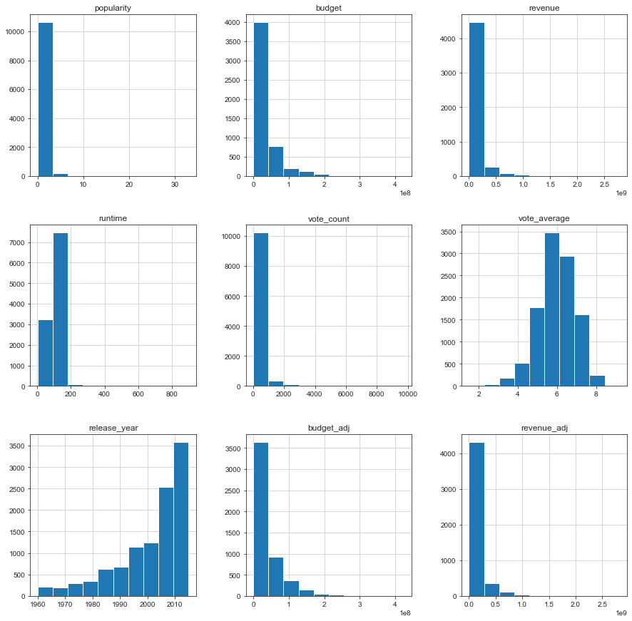

```python
# plot histogram
df.drop(['release_date'], axis=1).hist(figsize=( 15,15));
```

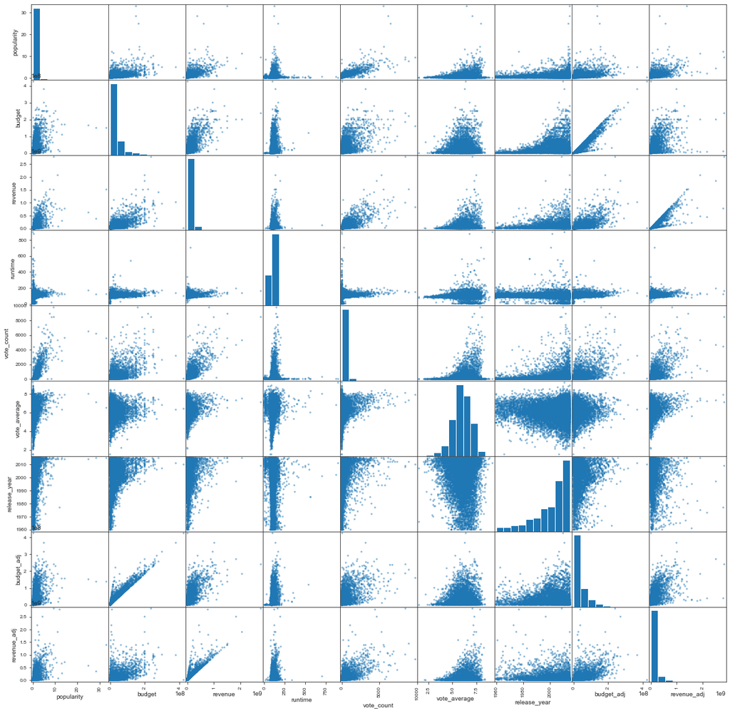

```python
# plot scatter matrix
pd.plotting.scatter_matrix(df.drop(['release_date'], axis=1), figsize=(20,20));
```

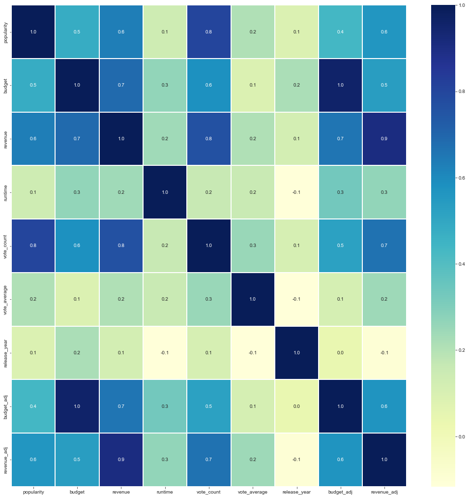

```python
# plot correlations
f, ax= plt.subplots(figsize=(18,18))
sns.heatmap(df.drop(['release_date'], axis=1).corr(), annot=True, linewidths=.3, cmap="YlGnBu", fmt='.1f', ax=ax)
plt.show()
```

## Exploratory Data Analysis

### Research Question 1 (How many movies were released in each genre? )

The `‘genres’` column contain multiple values separated by pipe `(|)` characters. I need each value of `‘genres’` to be on a single row.

```python
# check the data type of the contents of 'genres'
print(type(df['genres'][0]))
df.genres[0]
```

```
<class 'str'>
```

```
'Action|Adventure|Science Fiction|Thriller'
```

Need to convert contents of `'genres'` from ~`str`~ to `list`.

```python
# copy df DataFrame to a new DataFrame which will be used for the analysis of genre information
df_genres = df.copy()
# confirm copy
df_genres.head(1)
```

|  | popularity | budget | revenue | original_title | cast | director | runtime | genres | release_date | vote_count | vote_average | release_year | budget_adj | revenue_adj |
| --- | --- | --- | --- | --- | --- | --- | --- | --- | --- | --- | --- | --- | --- | --- |
| 0 | 32.985763 | 150000000.0 | 1.513529e+09 | Jurassic World | Chris Pratt\|Bryce Dallas Howard\|Irrfan Khan\|Vi... | Colin Trevorrow | 124 | Action\|Adventure\|Science Fiction\|Thriller | 2015-06-09 | 5562 | 6.5 | 2015 | 1.379999e+08 | 1.392446e+09 |

```python
# convert 'genres' content from str to list
df_genres['genres'] = df_genres['genres'].str.split('|')
# confirm the conversion to list
print(type(df_genres['genres'][0]))
df_genres.genres[0]
```

```
<class 'list'>
```

```
['Action', 'Adventure', 'Science Fiction', 'Thriller']
```

Now need the elements in all genres lists to be in a separate row in order to be able to count them.

```python
# use explode function o transform each element of a list-like to a row
df_genres = df_genres.explode('genres')
# confirm the changes
df_genres.head()
```

|  | popularity | budget | revenue | original_title | cast | director | runtime | genres | release_date | vote_count | vote_average | release_year | budget_adj | revenue_adj |
| --- | --- | --- | --- | --- | --- | --- | --- | --- | --- | --- | --- | --- | --- | --- |
| 0 | 32.985763 | 150000000.0 | 1.513529e+09 | Jurassic World | Chris Pratt\|Bryce Dallas Howard\|Irrfan Khan\|Vi... | Colin Trevorrow | 124 | Action | 2015-06-09 | 5562 | 6.5 | 2015 | 1.379999e+08 | 1.392446e+09 |
| 0 | 32.985763 | 150000000.0 | 1.513529e+09 | Jurassic World | Chris Pratt\|Bryce Dallas Howard\|Irrfan Khan\|Vi... | Colin Trevorrow | 124 | Adventure | 2015-06-09 | 5562 | 6.5 | 2015 | 1.379999e+08 | 1.392446e+09 |
| 0 | 32.985763 | 150000000.0 | 1.513529e+09 | Jurassic World | Chris Pratt\|Bryce Dallas Howard\|Irrfan Khan\|Vi... | Colin Trevorrow | 124 | Science Fiction | 2015-06-09 | 5562 | 6.5 | 2015 | 1.379999e+08 | 1.392446e+09 |
| 0 | 32.985763 | 150000000.0 | 1.513529e+09 | Jurassic World | Chris Pratt\|Bryce Dallas Howard\|Irrfan Khan\|Vi... | Colin Trevorrow | 124 | Thriller | 2015-06-09 | 5562 | 6.5 | 2015 | 1.379999e+08 | 1.392446e+09 |
| 1 | 28.419936 | 150000000.0 | 3.784364e+08 | Mad Max: Fury Road | Tom Hardy\|Charlize Theron\|Hugh Keays-Byrne\|Nic... | George Miller | 120 | Action | 2015-05-13 | 6185 | 7.1 | 2015 | 1.379999e+08 | 3.481613e+08 |

Now each row contains a single genre.

```python
# Count movies for each genre
count_movie_genres = df_genres['genres'].value_counts()
count_movie_genres
```

```
Drama              4751
Comedy             3782
Thriller           2905
Action             2382
Romance            1705
Horror             1629
Adventure          1470
Crime              1353
Family             1229
Science Fiction    1228
Fantasy             915
Mystery             808
Animation           699
Documentary         517
Music               401
History             334
War                 270
Foreign             187
Western             165
TV Movie            164
Name: genres, dtype: int64
```

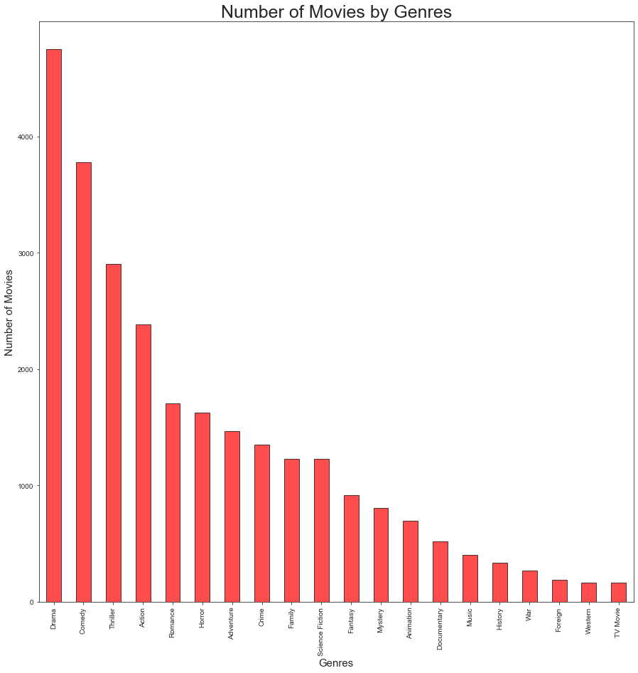

```python
# plot bar chart for the result
plt.title('Number of Movies by Genres', fontsize=25)
plt.xlabel('Genres', fontsize=15)
plt.ylabel('Number of Movies', fontsize=15)
count_movie_genres.plot(kind='bar', color='Red', edgecolor='Black', alpha=0.7, figsize=(15,15));
```

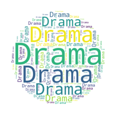

```python
text = "Drama"

x, y = np.ogrid[:300, :300]

mask = (x - 150) ** 2 + (y - 150) ** 2 > 130 ** 2
mask = 255 * mask.astype(int)


wc = wordcloud.WordCloud(background_color="white", repeat=True, mask=mask)
wc.generate(text)

plt.imshow(wc)
plt.axis("off")
plt.show()
```

**Drama** is the genre with the highest number of movies!

### Research Question 2 (Which genres are most popular from year to year?)

```python
# create a new DataFrame with the required columns
df_genres_pop = df_genres[['release_year', 'genres', 'popularity']]
# check the new dataframe
df_genres_pop.head()
```

|  | release_year | genres | popularity |
| --- | --- | --- | --- |
| 0 | 2015 | Action | 32.985763 |
| 0 | 2015 | Adventure | 32.985763 |
| 0 | 2015 | Science Fiction | 32.985763 |
| 0 | 2015 | Thriller | 32.985763 |
| 1 | 2015 | Action | 28.419936 |

```python
# calculate mean popularity for each genre grouped by 'release_year'
df_genres_pop =df_genres_pop.groupby(['release_year', 'genres'], as_index=False)['popularity'].mean()
# check result
df_genres_pop.head()
```

|  | release_year | genres | popularity |
| --- | --- | --- | --- |
| 0 | 1960 | Action | 0.590724 |
| 1 | 1960 | Adventure | 0.700981 |
| 2 | 1960 | Comedy | 0.396000 |
| 3 | 1960 | Crime | 0.346479 |
| 4 | 1960 | Drama | 0.566305 |

```python
# find most popular for each year, by selecting row with highest value in group
df_genres_pop = df_genres_pop.groupby('release_year', as_index=False).apply(lambda x: x.loc[x['popularity'] == x['popularity'].max()]).reset_index(drop=True)
df_genres_pop.head()
```

|  | release_year | genres | popularity |
| --- | --- | --- | --- |
| 0 | 1960 | Thriller | 0.811910 |
| 1 | 1961 | Animation | 2.631987 |
| 2 | 1962 | Adventure | 0.942513 |
| 3 | 1963 | Animation | 2.180410 |
| 4 | 1964 | War | 0.930959 |

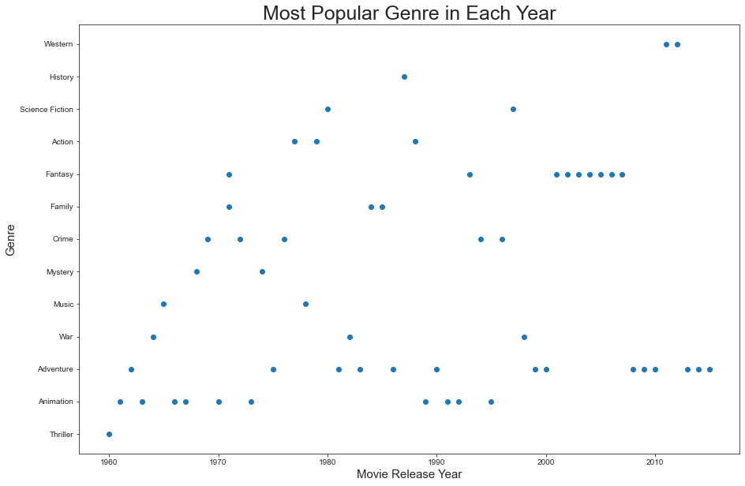

```python
plt.figure(figsize=(15,10))
plt.title('Most Popular Genre in Each Year', fontsize=25)
plt.xlabel('Movie Release Year', fontsize=15)
plt.ylabel('Genre', fontsize=15)
plt.scatter(df_genres_pop['release_year'], df_genres_pop['genres']);
```

[figure not shown]

```python
# set chart dimension
plt.figure(figsize=(15,10))
# heatmap plot
sns.heatmap(df_genres_pop.groupby(['release_year','genres'])['popularity'].mean().unstack('release_year'), cmap="rocket_r")

# set title
plt.title('Most Popular Genre in Each Year')
plt.xlabel('Genre')
plt.ylabel('Movie Release Year');
```

**Thriller** was the popular gener of year **1960**, while **Adventure** was the popular gener for the last three years **2013**, **2014**, and **2015**.

### Research Question 3 (Which genre(s) is/are all the time popular?)

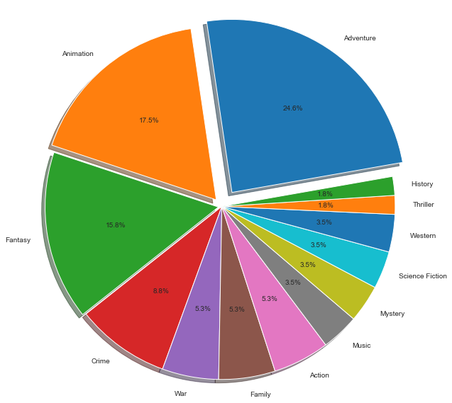

```python
# Pie chart, where the slices of genres will be ordered and plotted counter-clockwise:
labels = df_genres_pop.genres.value_counts().index
sizes = df_genres_pop.genres.value_counts().values
explode = (0.1, 0.05, 0.02, 0, 0, 0, 0, 0, 0, 0, 0, 0, 0) #explode only the top 3 genres

fig1, ax1 = plt.subplots()
fig1.set_size_inches(10, 10)
ax1.pie(sizes, explode=explode, labels=labels, autopct='%1.1f%%',
        shadow=True, startangle=10)
ax1.axis('equal')  # Equal aspect ratio ensures that pie is drawn as a circle.

plt.show()
```

### Research Question 4 (Which movie title was repeated the most and which release was the most popular?)

```python
# create DataFrame with required columns
df_movie =df[['original_title', 'release_year', 'popularity']]
# select repeated movie titles
df_movie = df_movie[df_movie.original_title.duplicated(keep=False)]
# create a new column containing the value counts of repeated movie titles
df_movie['counts'] = df_movie.groupby(['original_title'])['release_year'].transform('count')
# sort original titles by the highest count
df_movie.sort_values(['counts','release_year'], ascending=False).reset_index(drop=True)
```

|  | original_title | release_year | popularity | counts |
| --- | --- | --- | --- | --- |
| 0 | Hamlet | 2009 | 0.086490 | 4 |
| 1 | Hamlet | 2000 | 0.277798 | 4 |
| 2 | Hamlet | 1996 | 0.383469 | 4 |
| 3 | Hamlet | 1990 | 0.067973 | 4 |
| 4 | Life | 2015 | 0.560423 | 3 |
| ... | ... | ... | ... | ... |
| 563 | The Time Machine | 1960 | 0.712389 | 2 |
| 564 | Ocean's Eleven | 1960 | 0.423531 | 2 |
| 565 | The Alamo | 1960 | 0.310398 | 2 |
| 566 | The Lost World | 1960 | 0.144106 | 2 |
| 567 | Village of the Damned | 1960 | 0.127219 | 2 |

568 rows × 4 columns

**Hamlet** is the movie which was released the most. It was reased 4 times, in **1990**, **1996**, **2000** and **2009**. Let's check it's popularity.

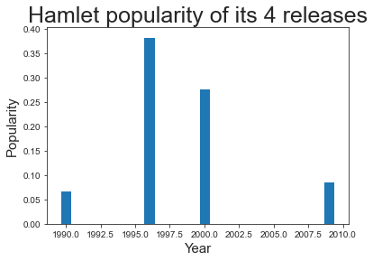

```python
# filter for for 'Hamlet'
df_hamlet = df_movie.query('original_title == "Hamlet"')
# plot bar chart to compare movie popularity
height = df_hamlet.popularity
x = df_hamlet.release_year
plt.title('Hamlet popularity of its 4 releases', fontsize=25)
plt.xlabel('Year', fontsize=15)
plt.ylabel('Popularity', fontsize=15)
plt.bar(x, height);
```

The most popular release of **Hamlet** was the release in **1996**.

### Research Question 5 (What kinds of properties are associated with genres that have high revenues?)

```python
#create new column ---- calculate net profit for each movie
df_genres['profit'] = df_genres['revenue'] - df['budget']
```

```python
# calculate the correlation
df_genres[['budget','revenue', 'profit', 'popularity']].corr()
```

|  | budget | revenue | profit | popularity |
| --- | --- | --- | --- | --- |
| budget | 1.000000 | 0.679458 | 0.517532 | 0.476336 |
| revenue | 0.679458 | 1.000000 | 0.979454 | 0.630133 |
| profit | 0.517532 | 0.979454 | 1.000000 | 0.596758 |
| popularity | 0.476336 | 0.630133 | 0.596758 | 1.000000 |

```python
# group by genres
df_genres_3 = df_genres.groupby('genres', as_index =False).agg({'budget':'sum','revenue':'sum','profit':'sum','popularity':'mean'})

#confirm grouping & calculation
df_genres_3.head()
```

|  | genres | budget | revenue | profit | popularity |
| --- | --- | --- | --- | --- | --- |
| 0 | Action | 6.610312e+10 | 1.735426e+11 | 1.086483e+11 | 0.926235 |
| 1 | Adventure | 5.522677e+10 | 1.664258e+11 | 1.111164e+11 | 1.153768 |
| 2 | Animation | 1.618869e+10 | 5.260399e+10 | 3.621719e+10 | 0.852182 |
| 3 | Comedy | 5.043299e+10 | 1.423370e+11 | 8.722096e+10 | 0.593997 |
| 4 | Crime | 2.391679e+10 | 5.736717e+10 | 3.327089e+10 | 0.745410 |

```python
# convert 'budget', 'revenue', and profit to billions
df_genres_3['revenue'] =df_genres_3['revenue']/1000000000
df_genres_3['profit'] =df_genres_3['profit']/1000000000
df_genres_3['budget'] =df_genres_3['budget']/1000000000
```

```python
# sort by highest revenue
df_genres_3 = df_genres_3.sort_values(by='revenue', ascending=False)
```

```python
df_genres_3
```

|  | genres | budget | revenue | profit | popularity |
| --- | --- | --- | --- | --- | --- |
| 0 | Action | 66.103124 | 173.542641 | 108.648335 | 0.926235 |
| 1 | Adventure | 55.226775 | 166.425794 | 111.116350 | 1.153768 |
| 3 | Comedy | 50.432994 | 142.337036 | 87.220957 | 0.593997 |
| 6 | Drama | 56.550217 | 139.145537 | 81.258694 | 0.592374 |
| 17 | Thriller | 50.019516 | 121.304510 | 72.776819 | 0.741917 |
| 7 | Family | 28.753344 | 89.165240 | 59.786616 | 0.787579 |
| 8 | Fantasy | 29.873128 | 88.223310 | 58.416626 | 0.991874 |
| 15 | Science Fiction | 30.691424 | 86.202746 | 56.024136 | 1.002023 |
| 14 | Romance | 21.453537 | 61.104657 | 39.001273 | 0.594030 |
| 4 | Crime | 23.916787 | 57.367168 | 33.270886 | 0.745410 |
| 2 | Animation | 16.188687 | 52.603987 | 36.217191 | 0.852182 |
| 13 | Mystery | 13.053359 | 32.576229 | 19.257824 | 0.691659 |
| 11 | Horror | 10.189578 | 27.538938 | 17.928052 | 0.466995 |
| 18 | War | 5.640809 | 12.853399 | 7.589371 | 0.727683 |
| 12 | Music | 3.850960 | 11.657282 | 7.736432 | 0.493940 |
| 10 | History | 6.210703 | 10.691939 | 5.250303 | 0.575936 |
| 19 | Western | 3.130728 | 4.713837 | 1.798058 | 0.590615 |
| 5 | Documentary | 0.300118 | 1.061376 | 0.618500 | 0.181698 |
| 9 | Foreign | 0.272870 | 0.285846 | 0.021909 | 0.192147 |
| 16 | TV Movie | 0.044700 | 0.042000 | 0.037000 | 0.273758 |

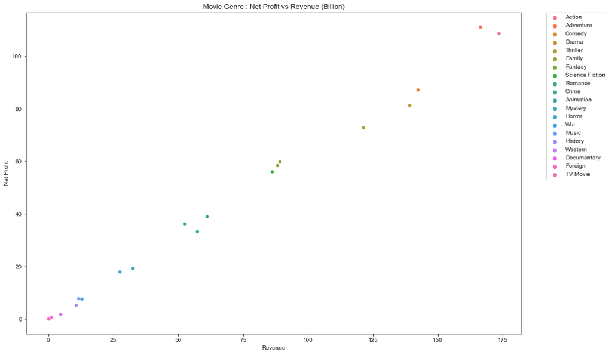

```python
# set chart dimension
plt.figure(figsize=(15,10))

# set plotting style
sns.set_style('ticks')

# set title
plt.title('Movie Genre : Net Profit vs Revenue (Billion)')
plt.xlabel('Revenue')
plt.ylabel('Net Profit')

#draw scatter plot
sns.scatterplot(x="revenue", y="profit", hue="genres", data=df_genres_3);

#move the legend outside the chart
plt.legend(bbox_to_anchor=(1.05, 1), loc='upper left', borderaxespad=0.);
```

Strong positive correlation, 0.979454 between revenue and profit.

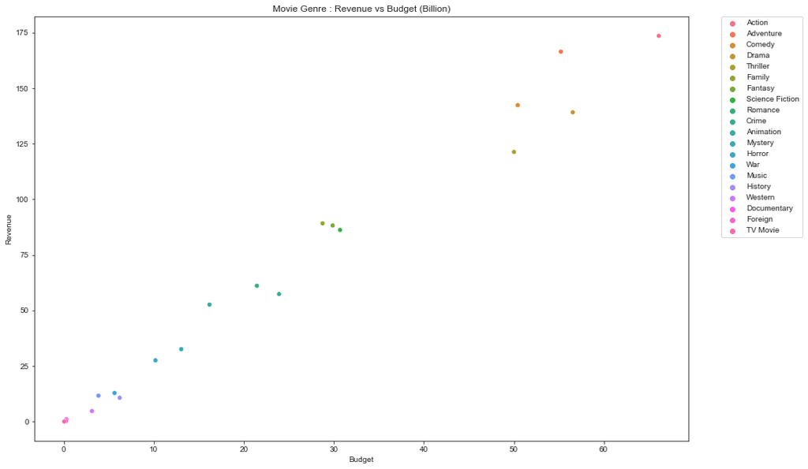

```python
# set chart dimension
plt.figure(figsize=(15,10))

# set plotting style
sns.set_style('ticks')

# set title
plt.title('Movie Genre : Revenue vs Budget (Billion)')
plt.xlabel('Budget')
plt.ylabel('Revenue')

# draw scatter plot
sns.scatterplot(x="budget", y="revenue", hue="genres", data=df_genres_3);

# move the legend outside the chart
plt.legend(bbox_to_anchor=(1.05, 1), loc='upper left', borderaxespad=0.);
```

As a conclusion: **Higher profit** and **higher budget** is associated with high revenue genres.

## Conclusions

> **Summary**:  
> Drama is the genre with the highest number of movies, followed by comedy and thriller.

> From 2000 to 2015 the popular geners were fantasy, adventure and western. While in 1960, popular gener was thriller.

> Most popular genre is adventure, followed by animation and fantasy.

> Hamlet was released 4 times. The most popular was in 1996. While the lease popular was the one released in 1990.

> **Limitations**:  
> One important limitation in the exploration is that a lot of data regarding (Production Companies) are missing.This could have added another insight if it was complete.  
> The (5,696, 6,016, 5,696, 6,016) zero values in `'budget'`, `'revenue'`, `'budget_adj'`, and `'revenue_adj'` is another limitation as more than 50% of date is missing.

## References:

> https://www.themoviedb.org/ https://datascienceparichay.com/article/insert-image-in-a-jupyter-notebook/  
> https://stackoverflow.com/questions/31361599/with-pandas-in-python-select-the-highest-value-row-for-each-group  
> https://pandas.pydata.org/docs/reference/api/pandas.DataFrame.explode.html  
> https://pandas.pydata.org/pandas-docs/stable/reference/api/pandas.DataFrame.groupby.html  
> https://amueller.github.io/word_cloud/auto_examples/single_word.html  
> https://pypi.org/project/wordcloud/  
> https://stackoverflow.com/questions/17709270/create-column-of-value-counts-in-pandas-dataframe

```python
from subprocess import call
call(['python', '-m', 'nbconvert', 'Investigate_a_Dataset.ipynb'])
```

```
1
```